# Manipulação de dados no Python

02 de maio de 2019

## Motivação

## Preparar. Apontar. Fogo!

- Manipular e visualizar dados (MVD) são atividades **obrigatórias** em Data Science (DS).
- A MVD **determina o sucesso** de uma série de etapas.
  - Entendimento dos dados.
  - Limpeza e conciliação de dados.
  - Engenharia de características.
  - Especificação de modelos.
  - Comunicação de resultados, etc.
- Fazer MVD de forma **eficiente** requer:
  - Conhecer o processo e suas etapas.
  - Dominar a tecnologia para execução.
- **Linguagens de programação** oferecem uma série de vantagens: reproduzível, extensível, escalonável, integrável, portável, etc.

## O tempo gasto

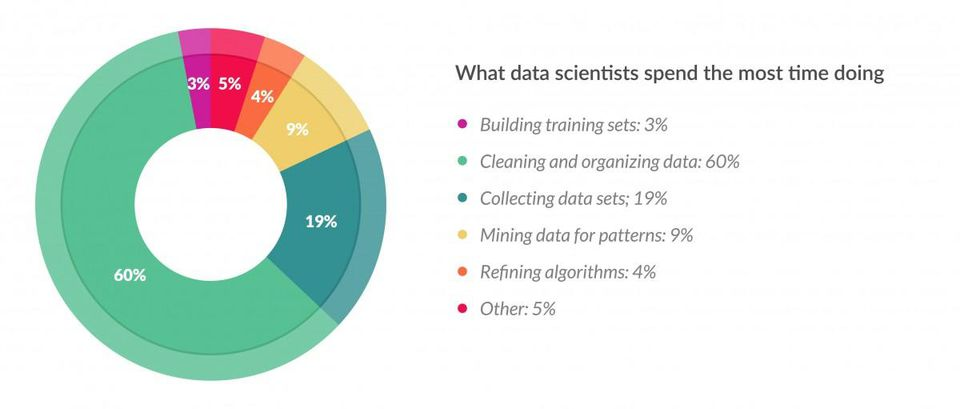

Tempo gasto nas atividades de Data Science. Fonte: https://www.forbes.com/sites/gilpress/2016/03/23/data-preparation-most-time-consuming-least-enjoyable-data-science-task-survey-says.

## O quanto (não) é divertido

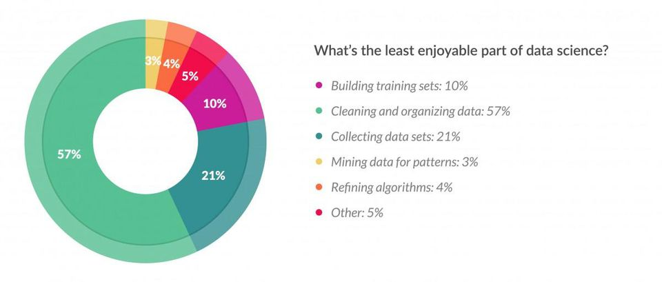

Quão enfadonhas são as atividades em Data Science. Fonte: https://www.forbes.com/sites/gilpress/2016/03/23/data-preparation-most-time-consuming-least-enjoyable-data-science-task-survey-says.

## Python para Ciência de Dados

## Principais bibliotecas

1. Análise exploratória de dados e computação científica.
   1. [Numpy](https://www.numpy.org/).
   2. [Scipy](https://www.scipy.org/).
   3. [Pandas](http://pandas.pydata.org/).
2. Visualização de dados.
   1. [Matplotlib](https://matplotlib.org/).
   2. [Seaborn](https://seaborn.pydata.org/).
3. Modelagem estatística.
   1. [Statsmodels](https://www.statsmodels.org).
   2. [Scikit-Learn](https://scikit-learn.org).

## Numpy

- Suporte de operações numéricas em Python.
- Estruturas para *arrays* (vetores/matrizes) multidimensionais.
- Operações matemáticas e estatísticas.
- Execução vetorizada das funções.
- Altamente otimizado para performance computacional.
- Código crítico em Cython, C e Fortran.
- Várias bibliotecas são baseada na [Numpy](https://www.numpy.org/).
- https://www.numpy.org/.
- Precursora da Numpy foi a Numeric em 1995.
- Numpy começou em 2006.
- Escrito em Python e C.

## Scipy

- Programação científica em Python.
- Reúne algorítmos/procedimentos para:
  - ÁLgebra linear.
  - Equações diferenciais.
  - Integração numérica.
  - Otimização.
  - Estatística.
- É baseada na [Numpy](https://www.numpy.org/).
- https://www.scipy.org/.

## Pandas

- Estrutura e métodos para manipulação de dados em formato tabular.
- Implementa a infraestrutura de `data.frame`s do R.
- Fornece operações para:
  - Leitura e escrita.
  - Ordenação e arranjo de disposição.
  - Seleção, fatiamento e filtragem.
  - Transformação e agregração.
  - Junções.
- http://pandas.pydata.org/.
- Primeira versão em Janeiro de 2008 por Wes McKinney.
- Escrita em Python, Cython e C.

## Matplotlib

- Biblioteca de gráficos 2D.
- Gera figuras em vários formatos.
- Similiar ao [Matlab](https://www.mathworks.com/products/matlab/plot-gallery.html) em aparência e construção.
- Gráficos de pontos, linhas, barras, setores, superfície, etc.
- Relativamente de baixo nível.
- Requer esforço para confecção de gráficos sofisticados.
- https://matplotlib.org/

## Seaborn

- Baseada na [Matplotlib](https://matplotlib.org/).
- Interface de alto nível para gráficos estatísticos.
- Similar ao [ggplot2](https://www.r-graph-gallery.com/portfolio/ggplot2-package/) em aparência.
- Compatibilidade com [Pandas](http://pandas.pydata.org/).

## Numpy

## Detalhes

- [Numpy](https://www.numpy.org/) é o pacote fundamental para computação científica em Python.
- Fornece *multimensional arrays* com operações vetorizadas.
- Amplo conjunto de funções para operar sobre *arrays*.
- Integração com C/C++ e Fortran.
- Recursos para álgebra linear, geração de números aleatórios e mais.
- https://www.numpy.org/.

## Importação da biblioteca

```python
# Importa a Numpy.
import numpy as np

# Consulta a versão e caminho para arquivos.
print(np.__version__)
```

```
1.16.3
```

```python
print(np.__path__)
# np.__spec__
# np.__doc__
```

```
['/home/walmes/anaconda3/lib/python3.7/site-packages/numpy']
```

```python
# Conteúdo carregado.
dir(np)
```

## Desempenho de operações vetorizadas

```python
from timeit import default_timer as tmr

l = list(range(100000000))
v = np.array(l)

i = tmr(); sum(l);  e = tmr(); a = e - i; a
i = tmr(); v.sum(); e = tmr(); b = e - i; b
a/b

u = 999
i = tmr(); y = [x * u for x in l]; e = tmr(); a = e - i; a
i = tmr(); f = v * u; e = tmr(); b = e - i; b
a/b

u = 100000
i = tmr(); f = [x for x in l if x > u]; e = tmr(); a = e - i; a
i = tmr(); f = v[v > u]; e = tmr(); b = e - i; b
a/b
```

```python
    # Soma. ---------------------------------
>>> i = tmr(); sum(l);  e = tmr(); a = e - i; a
0.5613289720001831
>>> i = tmr(); v.sum(); e = tmr(); b = e - i; b
0.06923460899997735
>>> a/b
8.107635474627532

    # Multiplicação. ------------------------
>>> u = 999
>>> i = tmr(); y = [x * u for x in l]; e = tmr(); a = e - i; a
4.931227970000009
>>> i = tmr(); f = v * u; e = tmr(); b = e - i; b
0.26028217999987646
>>> a/b
18.94569950967196

    # Teste lógico. -------------------------
>>> u = 100000
>>> i = tmr(); f = [x for x in l if x > u]; e = tmr(); a = e - i; a
3.547209543000008
>>> i = tmr(); f = v[v > u]; e = tmr(); b = e - i; b
0.6467253729999811
>>> a/b
5.484877648367929
```

## Arrays multidimensionais

- Arrays são estruturas que armazenam dados de mesmo tipo de valor.
- Existem várias funções para criar arrays multimensionais.
- São muito úteis os vetores:
  - de zeros e uns.
  - com sequências regulares.
  - repetições de vetores.
  - de números aleatórios.

## Criação de arrays

### Arrays a partir de listas

```python
# Um array unidimensional.
A = np.array([4, 7, 5, 1, 9, 7, 4, 0]); A
# Modifica as dimensões para redispor o conteúdo.
A.shape = (2, 4); A
# Um array tridimensional.
A.shape = (2, 2, 2); A
```

### Zeros, uns e outros

```python
# Vetor de 0.
np.zeros(shape = 4)
# Vetor de 1.
np.ones(shape = 4)
# Vetor vazio (nan).
np.empty(shape = 4)
# Vetor de algo qualquer.
np.full(shape = 4, fill_value = 99)
```

## Arrays regulares

### Sequências regulares

```python
# Sequências regulares.
np.arange(start = 0, stop = 12, step = 2)
np.linspace(start = 0, stop = 12, num = 7)
np.logspace(start = -3, stop = 3, num = 7, base = 2)
np.geomspace(start = 2**(-3), stop = 2**3, num = 7)
```

### Repetições

```python
# Repetições.
np.repeat(a = np.array([1, 2, 3]), repeats = 2)
np.repeat(a = np.array([[1, 2], [3, 4]]), repeats = 2, axis = 0)
np.repeat(a = np.array([[1, 2], [3, 4]]), repeats = 2, axis = 1)
np.repeat(a = np.array([[1, 2], [3, 4]]), repeats = [2, 1], axis = 0)
```

```python
# Isso pode ser obtido com soma direta ou Kronecker.
np.tile(A = [1, 2, 3], reps = 2)
np.tile(A = [1, 2, 3], reps = [3, 2])
np.tile(A = np.array([[1, 2], [3, 4]]), reps = [3, 2])
```

## Números aleatórios

- Números aleatórios são úteis em inúmeras situações em computação científica.
- Em estatística são centrais para simulação de modelos estatísticos, inferência Bayesiana por MCMC, métodos baseados em reamostragem, etc.

## Números aleatórios

### Vetores com números aleatórios

```python
# Números da distribuição uniforme contínua.
np.random.random(size = 3)
np.random.uniform(low = 0, high = 1, size = 4)
# Números da distribuição uniforme discreta.
np.random.randint(low = 0, high = 10, size = 20)

# Amostragem de um vetor de valores.
np.random.choice(a = [100, 200, 300], size = 7, replace = True)
# Números da distribuição normal.
np.random.normal(loc = 0, scale = 1, size = 4)
```

### Matrizes com números aleatórios

```python
# Arrays multimensionais da uniforme contínua e normal padrão.
np.random.rand(3, 4)
np.random.randn(3, 4)
```

## Seleção em arrays

```python
# Uma sequência regular.
A = np.linspace(start = 100, stop = 110, num = 11)
A

# Fatiamentos.
A[0:2]    # Do 0 até 1 inclusive.
A[:2]     # Idem.
A[2:]     # Do 2 até o final.
A[-2:]    # Do 2 de trás para frente até o final.
A[::2]    # Do começo ao final com passo 2.

# Conjuntos.
A[[1, 5, 9]]  # Na posição 1, 5 e 9.
A[[1, -5, 9]] # Nas posição 1, 5 vindo do final e 9.
```

```python
A = np.random.rand(3, 4)
A

A[0, :]      # Linha 0 e todas as colunas.
A[0:2, :]    # Linha 0 e 1 e todas as colunas.
A[:, 0:3]    # Todas as linhas e colunas até 2.
A[0:2, 0:3]  # Junção das anteriores.
```

## Filtros

### Operadores de comparação

```python
A = np.random.randint(low = 1, high = 5, size = 20)

A[A > 3]  # Maior.
A[A >= 3] # Maior ou igual.

A[A < 3]  # Menor.
A[A <= 3] # Menor ou igual

A[A == 3] # Igual
A[A != 3] # Diferente.
```

### Operadores lógigos

```python
# São as versões vetoriais de `and`, `or` e `not`.
A[(A > 8) & (A < 12)]  # Operador AND.
A[(A < 8) | (A > 12)]  # Operador OR.
A[~(A == 3)]           # Operador NOT.
```

## Principais operações matriciais

```python
A = np.random.rand(3, 4)
B = np.random.rand(4, 5)
C = np.random.rand(3, 3)
D = np.random.rand(4, 4)
```

```python
# Operações elemento a elemento (elementwise).
A + A
C - C
D * D
D / D
```

```python
# Produto matricial.
A.dot(B)
C.dot(A)

A.T              # Transposta.
np.diag(C)       # Diagonal.
np.linalg.inv(C) # Inversa.
np.linalg.det(C) # Determinante.
```

## Operações com arrays de dimensão diferente

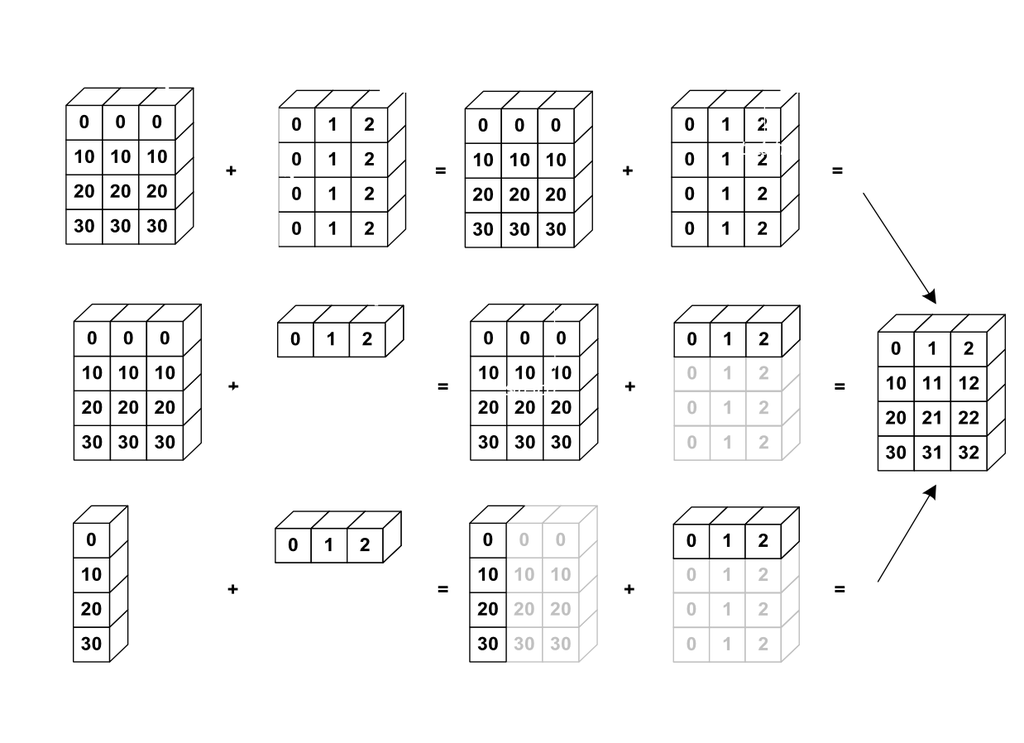

Operações de broadcasting da Numpy. Fonte: https://scipy-lectures.org/intro/numpy/operations.html.

## Operações aritméticas e estatísticas

### Disponíveis via métodos

```python
A = np.random.normal(loc = 10, scale = 1.5, size = 50)
[A.sum(), A.mean(), A.var(),
 A.std(), A.max(),  A.min()]
```

### Funções aplicáveis em arrays

```python
np.mean(a = A)
np.median(a = A)
np.quantile(a = A, q = [0.25, 0.75])
```

### Aplicação por dimensão

```python
B = np.random.rand(3, 4)
np.mean(a = B)
np.mean(a = B, axis = 0)
np.mean(a = B, axis = 1)
```

## Considerações

- Foi feito apenas uma revisão de [Numpy](https://www.numpy.org/).
- [Numpy](https://www.numpy.org/) é um módulo grande e é a base para outros vários módulos.
- O [Pandas](http://pandas.pydata.org/) é construído sobre o [Numpy](https://www.numpy.org/).

## Pandas

## Detalhes

- [Pandas](http://pandas.pydata.org/) é a biblioteca para manipulação de dados no Python.
- Implementa a estrutura de *Data Frame* e métodos que atuam sobre ele.
- Contém todas as operações usuais disponíveis em instruções SQL.
- Além destas, dispõe de funções estatísticas e recursos de visualização.
- Em termos de performance computacional, aproxima do `data.table` do R e empata com o `tidyverse`.

## Operações típicas de manipulação

1. Importar e/ou acessar dados.
2. Ordenar os registros da tabela.
3. Selecionar e fatiar nos índices/eixos.
4. Filtrar registros por predicado.
5. Renomear os índices/eixos.
6. Modificar a disposição do conteúdo.
7. Modificar/transformar o conteúdo.
8. Aplicar funções/calcular medidas resumo.
9. Agregar por categorias e aplicar.
10. Concatenar tabelas.
11. Juntar ou conciliar tabelas.

## Importar o módulo

```python
import pandas as pd

print(pd.__version__)
```

```
0.24.2
```

```python
print(pd.__path__)
```

```
['/home/walmes/anaconda3/lib/python3.7/site-packages/pandas']
```

```python
dir(pd)
```

```
Categorical, CategoricalDtype, CategoricalIndex, DataFrame,
DateOffset, DatetimeIndex, DatetimeTZDtype, ExcelFile,
ExcelWriter, Float64Index, Grouper, HDFStore, Index, IndexSlice,
..., api, array, arrays, bdate_range, compat, concat, core,
crosstab, cut, date_range, datetime, describe_option, errors,
eval, factorize, ..., to_datetime, to_msgpack, to_numeric,
to_pickle, to_timedelta, tseries, unique, util, value_counts,
wide_to_long
```

## Leitura de arquivos de dados

- As funções de leitura de arquivos do Pandas começam com `read_`.
- O argumento obrigatório é o caminho para o arquivo.
- Os demais são opcionais.

```python
# Lista as funções que possuem `read_` no nome.
d = [d for d in dir(pd) if "read_" in d]
d
```

```
read_clipboard, read_csv, read_excel, read_feather, read_fwf,
read_gbq, read_hdf, read_html, read_json, read_msgpack,
read_parquet, read_pickle, read_sas, read_sql, read_sql_query,
read_sql_table, read_stata, read_table
```

```python
# `pd.read_table()` é a função de leitura mais genérica.
args = pd.read_table.__code__.co_varnames
args
```

```
filepath_or_buffer, sep, delimiter, header, names, index_col,
usecols, squeeze, prefix, mangle_dupe_cols, dtype, engine, ...
```

## Exemplo de importação

- O caminho para o arquivo pode ser uma URL.
- A função faz a conexão e download do arquivo.

```python
# Endereço web do arquivo, mas poderia ser local.
url = "http://leg.ufpr.br/~walmes/data/euro_football_players.txt"

# Importa a tabela de dados.
tb = pd.read_table(filepath_or_buffer = url,
                   sep = "\t",
                   comment = "#")
```

```python
tb.head(n = 6)
```

```
   country      team               name   pos   age  ...  spg    ps   aw  mom    rt
0  Austria  Salzburg         Sadio Mané  M(L)  21.0  ...  2.0  77.0  1.2  3.0  7.98
1  Austria  Salzburg        Kevin Kampl  M(R)  23.0  ...  2.0  83.9  0.3  1.0  7.93
2  Austria  Salzburg               Alan    FW  24.0  ...  4.2  60.8  3.8  2.0  7.91
3  Austria  Salzburg      André Ramalho  D(C)  22.0  ...  0.9  72.3  3.2  1.0  7.67
4  Austria  Salzburg  Stefan Hierländer     M  23.0  ...  0.5  86.3  3.0  NaN  7.59
5  Austria  Salzburg  Christoph Leitgeb  M(C)  28.0  ...  1.6  79.4  0.5  NaN  7.55

[6 rows x 17 columns]
```

## Atributos do objeto

- A função `type()` retorna a classe do objeto.
- A função `dir()` exibe o conteúdo e um objeto que, no caso de DataFrame, mistura atributos, métodos e variáveis da tabela.
- Para uma exibição mais detalhada pode se usar o módulo [`see`](https://pypi.org/project/see/).
- A `see()` permite aplicação de filtros para exibir conteúdo selecionado.
- Para acessar apenas o nome dos índices use `.index` e `.columns`

```python
type(tb) # Classe.
dir(tb)  # Conteúdo.
```

```python
# Principais atributos.
tb.shape
tb.index
tb.columns
```

## Informações sobre a tabela

```python
tb.info()
```

```
<class 'pandas.core.frame.DataFrame'>
RangeIndex: 1528 entries, 0 to 1527
Data columns (total 17 columns):
country    1528 non-null object
team       1528 non-null object
name       1528 non-null object
pos        1528 non-null object
age        1524 non-null float64
cm         1444 non-null float64
kg         1417 non-null float64
apps       1326 non-null object
goal       412 non-null float64
ass        362 non-null float64
yel        729 non-null float64
red        95 non-null float64
spg        1025 non-null float64
ps         1318 non-null float64
aw         1120 non-null float64
mom        277 non-null float64
rt         1326 non-null float64
dtypes: float64(12), object(5)
memory usage: 203.0+ KB
None
```

## Métodos e funções

```python
import see

# Exibe todo conteúdo.
dot = see.see(tb)
dot
```

```
.*, [], in, +, +=, -, -=, *, *=, @, /, /=, //, //=, %, %=, **,
**=, &, &=, ^, ^=, |, |=, +obj, -obj, ~, <, <=, ==, !=, >, >=,
abs(), bool(), dir(), hash(), help(), iter(), len(), repr(),
round(), str(), unicode(), .T, .abs(), .add(), .add_prefix(),
.add_suffix(), .age, .agg(), .aggregate(), .align(), .all(),
.any(), .append(), .apply(), .applymap(), .apps, .as_matrix(),
.asfreq(), .asof(), .ass, .assign(), .astype(), .at(), .at_time(),
.aw, .axes, .between_time(), ...
```

```python
# Exibe apenas o que termina com () -> funções.
dot.filter('/()$/')

# Exibe apenas o que NÃO termina com `()` -> atributos e operadores.
dot.filter('/[^(][^)]$/')
```

## Criação a partir de objetos Python

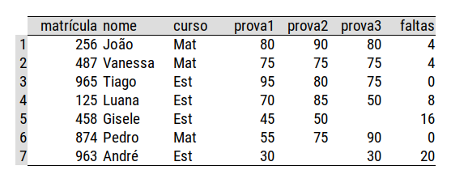

Uma tabela com dados fictícios.

## Criação a partir de objetos Python

### Por dicionário orientado à variáveis

```python
# Cria um DataFrame a partir de um dicionário. O dicionário é de
# colunas: um dicionário de arrays.
df1 = pd.DataFrame({
    "matricula": [256, 487, 965, 125, 458, 874, 963],
    "nome": ["João", "Vanessa", "Tiago", "Luana", "Gisele",
             "Pedro", "André"],
    "curso": ["Mat", "Mat", "Est", "Est", "Est", "Mat", "Est"],
    "prova1": [80, 75, 95, 70, 45, 55, 30],
    "prova2": [90, 75, 80, 85, 50, 75, None],
    "prova3": [80, 75, 75, 50, None, 90, 30],
    "faltas": [4, 4, 0, 8, 16, 0, 20]},
                       index = list(range(1, 8)))
df2 = pd.DataFrame({
    "matricula": [505, 658, 713],
    "nome": ["Bia", "Carlos", "Cris"],
    "curso": ["Eng", "Eng", "Eng"],
    "prova1": [65, 75, 75],
    "prova2": [85, 80, 90],
    "faltas": [0, 0, 2]},
                       index = list(range(1, 4)))
```

## Criação a partir de objetos Python

### Por dicionário orientado à observações

```python
# Cria um DataFrame a partir de um array de dicionários. Informação
# organizada por tupla ou registro.
df_extra = pd.DataFrame([
    {"mat.": 256, "nome": 'João'  , "idade": 18, "bolsista": "S"},
    {"mat.": 965, "nome": 'Tiago' , "idade": 18, "bolsista": "N"},
    {"mat.": 285, "nome": 'Tiago' , "idade": 22, "bolsista": "N"},
    {"mat.": 125, "nome": 'Luana' , "idade": 21, "bolsista": "S"},
    {"mat.": 874, "nome": 'Pedro' , "idade": 19, "bolsista": "N"},
    {"mat.": 321, "nome": 'Mia'   , "idade": 18, "bolsista": "N"},
    {"mat.": 669, "nome": 'Luana' , "idade": 19, "bolsista": "S"},
    {"mat.": 967, "nome": 'André' , "idade": 20, "bolsista": "N"},
])
```

## Ordenação

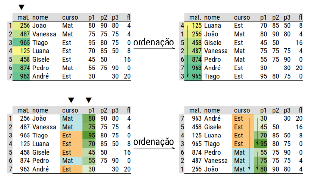

Ordenação dos registros de uma tabela.

## Ordenação

```python
df1.sort_values(by = "matricula", ascending = True)
```

```
   matricula     nome curso  prova1  prova2  prova3  faltas
4        125    Luana   Est      70    85.0    50.0       8
1        256     João   Mat      80    90.0    80.0       4
5        458   Gisele   Est      45    50.0     NaN      16
2        487  Vanessa   Mat      75    75.0    75.0       4
6        874    Pedro   Mat      55    75.0    90.0       0
7        963    André   Est      30     NaN    30.0      20
3        965    Tiago   Est      95    80.0    75.0       0
```

```python
df1.sort_values(by = ["curso", "prova1"],
                ascending = [True, True])
```

```
   matricula     nome curso  prova1  prova2  prova3  faltas
7        963    André   Est      30     NaN    30.0      20
5        458   Gisele   Est      45    50.0     NaN      16
4        125    Luana   Est      70    85.0    50.0       8
3        965    Tiago   Est      95    80.0    75.0       0
6        874    Pedro   Mat      55    75.0    90.0       0
2        487  Vanessa   Mat      75    75.0    75.0       4
1        256     João   Mat      80    90.0    80.0       4
```

```python
df1.sort_values(by = ["matricula"], inplace = True)
```

## Seleção e fatiamento

### Nomes

```python
# Nome dos índices de coluna (axis = 1).
df1.columns
df2.columns

# Nome dos índices de linha (axis = 0).
df1.index
df2.index
```

### Tamanho

```python
# Número de linhas e colunas.
df1.shape
df2.shape

# Número de cédulas.
df1.size
df2.size
```

## Seleção das variáveis (colunas)

### Seleção com lista de índices

```python
# Seleção das variáveis.
df1["nome"]
df1[["nome", "prova1", "prova2", "prova3"]]
```

```python
# Usando `.loc`.
df1.loc[:, ["nome", "prova1", "prova2", "prova3"]]
```

### Seleção pela posição

```python
# Usando `.iloc`.
df1.iloc[:, :3]
df1.iloc[:, -3:]
df1.iloc[:, [1, 4]]
df1.iloc[:, range(0, 3)]
```

## Questão!

1. Como selecionar apenas as posições pares?
2. Como selecionar um conjunto de intervalos: 1 a 3 e 5 a 8?
3. Como selecionar todas exceto as variáveis de uma lista?
4. Como selecionar de acordo com o tipo de valor: apenas a variáveis de tipo numérico?
5. Como selecionar variáveis baseado em padrões de caracteres (regex)?

## Solução

```python
# Apenas as pares.
df1.iloc[:, ::2]
```

```python
# Concatenação de listas vindas de intervalos.
df1.iloc[:, list(range(0, 2)) + list(range(3, 4))]
```

```python
# Compreensão de lista.
v = ["prova1", "prova2", "prova3"]
sel = [i for i in df1.columns if not i in v]
df1.loc[:, sel]                  # Seleção.
df1.loc[:, ~df1.columns.isin(v)] # Negação (`~`).
```

```python
# Apenas as de tipo numérico (`float64`).
type(df1.dtypes)
sel = df1.dtypes == "int64"
df1.loc[:, sel]
```

```python
# Seleção de variáveis por padrão de caracteres (regex).
df1.filter(regex = "^prova") # Começa com "prova".
df1.filter(regex = "\d$")    # Termina com número.
df1.filter(regex = "^.{6}$") # Palavra tem 6 algarismos.
```

## Seleção de observações (linhas)

### Usando fatiadores

```python
# Seleção por posição (só vale slicing, i.e. criados com `:`).
df1[:1]
df1[-2:]
df1[0:4:2]
df1[slice(0, 4, 2)]
```

### Por lista de posições

```python
# Seleção por posição mais geral.
df1.iloc[0:2, ]
df1.iloc[-2:, ]
df1.iloc[range(0, 2), ]
df1.iloc[list(range(0, 2)) + list(range(3, 4)), ]
```

## Seleção de observações (linhas)

### Pelo nome dos índices

```python
# Convertendo uma coluna para índice dos registros.
df1.set_index("nome", inplace = True)
df1.index
```

```python
# Seleciona pelo nome dos índices.
df1.loc[["Aline", "Vanessa"], :]
```

```python
# Restaura a indexão.
df1.reset_index(inplace = True)
df1.index
```

### Por máscara lógica

```python
# Vetor aleatório de valores lógicos.
i = np.random.choice([True, False], size = df1.shape[0],
                     replace = True, p = [0.4, 0.6])
# Mantém posições que aparecem o True.
df1[i]
```

## Seleção de registros

```python
# Só permite o uso de escalares.
df1.at[3, "nome"] # Com índices rotulados.
df1.iat[3, 0]     # Com posição.
```

## Filtros

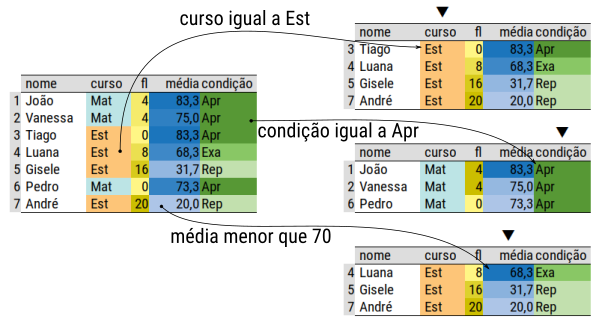

Filtro dos registros de uma tabela.

## Filtros

### Um vetor lógico

```python
# Usando regras lógicas (máscaras lógicas).
df1[df1.curso == "Est"]
df1[df1.faltas == 0]
df1[df1.faltas != 0]
df1[df1.nome.isin(["Aline", "Vanessa"])]
```

### Combinando vetores lógicos

```python
df1[(df1.prova1 >= 7) & (df1.prova2 >= 7)]
df1[(df1.prova1 + df1.prova2 + df1.prova3)/3 >= 7]
```

```python
# Lista dos aprovados e reprovados em cálculo.
mask = ((df1.prova1 + df1.prova2 + df1.prova3) >= 21) &\
       (df1.faltas < 15)
df1[mask]  # Não reprovados (aprovados e exame).
df1[~mask] # Os reprovados (`~` é o operador `not` vetorial).
```

## Questão!

1. Existe algum jeito de não ficar precedendo o nome das variáveis na construção da regra lógica?
2. Tem como aplicar regras lógicas sobre variáveis criadas *on the fly*?

## Solução

```python
df1.query("prova1 >= 6")
df1.query("prova1 >= 6 & prova2 >= 6")
df1.query("(prova1 + prova2)/2 >= 6")
df1.query("(prova1 + prova2)/2 >= 6 & faltas < 2")
```

```python
# Seleção de variáveis por padrão de nome.
df1.filter(regex = "^prova") # Começa com "prova".
df1.filter(regex = "\d$")    # Termina com número.
df1.filter(regex = "^.{6}$") # Palavra tem 6 algarismos.
```

## Renomeação

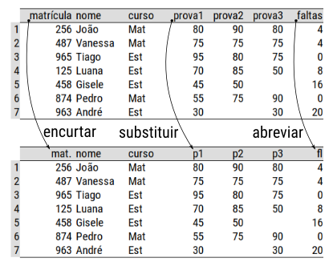

Formas de renomear as colunas de uma tabela.

## Renomeação

### Via dicionário de substituição

```python
# Renomeia índices de coluna (variáveis).
df1.rename(columns = {"matricula": "mat.", "faltas": "fl"})
```

```python
# Renomeia índices de linhas (index).
df1.rename(index = {0: "10", 1: "20"})
```

### Função de transformação de *strings*

```python
# Usando métodos para strings. Deixa caixa alta, capitaliza e trunca.
df1.rename(mapper = str.upper, axis = "columns")
df1.rename(mapper = str.capitalize, axis = "columns")
df1.rename(mapper = lambda x: x[:3] + x[-1:], axis = "columns")
df1.rename(mapper = lambda x: x.replace("prova", "p"), axis = "columns")
```

## Renomeação

### Operações de expressão regular

```python
# Usando expressão regular (regex).
import re

# Separa o número do texto com um underline.
df1.rename(columns = lambda x: re.sub(pattern = "^(.*)(\d)$",
                                      repl = "\\1_\\2",
                                      string = x))
```

## Transformação

As operações podem modificar a tabela com a:

1. **Criação** de novas variáveis.
2. **Remoção** de variáveis.
3. **Transformação** de variáveis.

As operações de criação/transformação podem ser:

1. **Matemáticas**: aritméticas, potência, logarítmicas, trigonométricas, etc.
2. **Compartimentação** (*binning*): agrupar em classes.
3. **Conversão** de tipo de valor: i.e. de `int` \(\rightarrow\) `str`.
4. **Substituição**: i.e. preencher um valor ausente.

## Transformação

As transformações podem ser:

1. Uma \(\rightarrow\) uma: \[ y = \log(x). \]
2. Várias \(\rightarrow\) uma: \[ z = x/y^2. \]
3. Várias \(\rightarrow\) várias: \[ y_1, \cdots, y_k = f_1(x_1,\cdots,x_m), \cdots, f_k(x_1, \cdots, x_m). \]

## Transformações

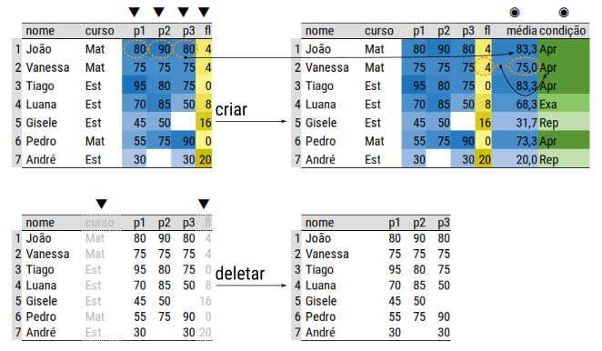

Criação e deleção de variáveis em uma tabela.

## Transformações

### Transformações matemáticas

```python
# Adiciona a coluna com a média.
df1["media"] = (df1.prova1 + df1.prova2 + df1.prova3)/3
# Outra forma de fazer.
df1["media"] = df1.loc[:, ["prova1", "prova2", "prova3"]].\
                   transform(sum, axis = 1)/3
df1["media"] = df1.media.round(decimals = 2)
df1
```

```python
# Outra forma de fazer usando função anônima.
df1.apply(func = lambda r: (r.prova1 + r.prova2 + r.prova3)/3, axis = 1)
```

## Transformações

### Transformações matemáticas homogêneas

```python
# Transformações com funções de uma variável.
df1.faltas.transform(np.sqrt)
df1.faltas.transform([np.sqrt, np.log]) # Funções Numpy.
df1.faltas.transform(["sqrt", "log"])   # Métodos Pandas.
df1.faltas.transform(lambda x: np.power(x, 2))
```

```python
# Funções aplicadas em várias variáveis
df1.loc[:, ["prova1", "prova2"]].transform([np.sqrt, np.log])
df1.loc[:, ["prova1", "prova2"]].apply([np.sqrt, np.log])
```

## Transformações

### Compartimentação

```python
# Intervalos para corte e rótulos.
inter = [0, 4, 7, np.inf]
condi = ["reprovado", "exame", "aprovado"]

# Cria a variável que é a condição.
df1["condicao"] = pd.cut(x = df1["media"],
                         bins = inter,
                         labels = condi,
                         right = False,
                         include_lowest = True)
df1
```

## Transformações

### Conversão ou coerção

```python
df1.matricula.transform(str)
df1.matricula.transform(float)

df1.matricula.astype(str)
df1.matricula.astype(float)
```

## Transformações

### Substituição

```python
# Máscara lógica.
df1.prova2.isnull()
df1.prova2.notnull()

# Troca NaN por 0.
df1.loc[:, ["prova1", "prova2", "prova3"]].fillna(0)

# Troca o NaN por 0 permanente.
df1.fillna({"prova1": 0, "prova2": 0, "prova3": 0},
           inplace = True)
df1
```

## Transformações

### Remoção

```python
df1["media"] = (df1.prova1 + df1.prova2 + df1.prova3)/3
df1

del df1["media"]
del df1["condicao"]
df1
```

## Variáveis de tipo especial

O Pandas tem recursos para trabalhar com variáveis de tipo especial. Neste tutorial elas não serão abordadas. Consulte a documentação disponível.

1. Variáveis **categóricas**: https://pandas.pydata.org/pandas-docs/stable/user_guide/categorical.html.
2. Variáveis **cronológicas**: https://pandas.pydata.org/pandas-docs/stable/user_guide/timeseries.html.
3. Variáveis **textuais** (strings): https://pandas.pydata.org/pandas-docs/stable/user_guide/text.html.
4. Valores **ausentes**: https://pandas.pydata.org/pandas-docs/stable/user_guide/missing_data.html.
5. Estruturas **esparsas**: https://pandas.pydata.org/pandas-docs/stable/user_guide/sparse.html.

## Rearranjo

- São operações de *reshaping* da tabela.
- Modificam a disposição dos registros.
  - Empilhar ou amontoar um conjunto de variáveis.
  - Desempilhar ou esparramar os níveis de uma variável.

## Rearranjo · Empilhar

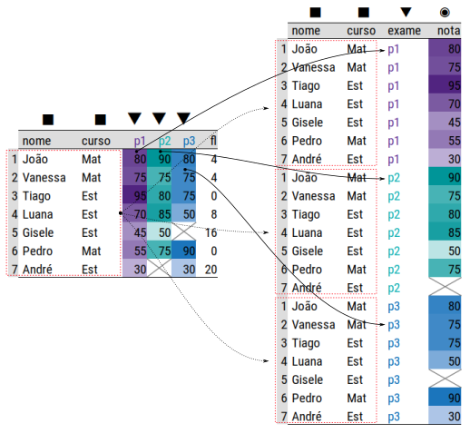

Modificação da disposição com empilhamento.

## Rearranjo · Esparramar

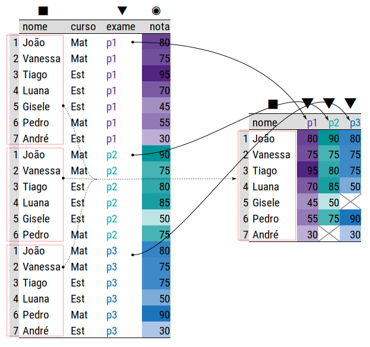

Modificação da disposição com desempilhamento.

## Rearranjo

### Usando o índice de linhas

```python
# Use um index apropriado.
df1.set_index("nome", inplace = True)
df1

# As funções stack() e unstack().
df1_s = df1.loc[:, ["prova1", "prova2", "prova3"]].stack()
df1_s
df1_s.index

df1_u = df1_s.unstack()
df1_u
df1_u.index
```

- Os `NaN` são removidos.
- `df1_s` é de classe `Series` com index multinível.
- `df1_u` é de classe `DataFrame`.

## Rearranjo

### Não usando o índice de linhas

```python
# As funções melt() e pivot().
df1.reset_index(inplace = True)
df1_m = df1.melt(id_vars = ["nome", "curso"],
                 value_vars = ["prova1", "prova2", "prova3"],
                 var_name = "exame",
                 value_name = "nota")
df1_m

df1_p = df1_m.pivot(index = "nome",
                    columns = "exame",
                    values = "nota").reset_index()
df1_p.columns.name = None
df1_p
```

- `df1_m` e `df1_p` são de classe `DataFrame`.
- `NaN` são mantidos.
- A `.pivot()` só permite uma variável em `index =`.

## Medidas resumo

- Operações para determinar estatísticas descritivas.
  - Soma, média, mediana, quartis, quantis, etc.
  - Variância, desvio-padrão, amplitude, desvio absoluto da mediana, coeficiente de variação, etc.
  - Número de níveis distintos, frequências absolutas/relativas, etc.
- Elas podem ser marginais ou considerar a estratificação conforme uma ou mais variáveis categóricas.
- Podem ser aplicadas em todas as variáveis de um mesmo tipo (homegêneo).

## Medidas resumo

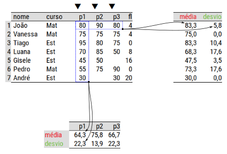

Cálculo de medidas resumo.

## Medidas resumo

### Uma variável ou uma estatística

```python
# Retornam um valor.
[df1.prova1.sum(), df1.prova1.mean(),
 df1.prova1.min(), df1.prova1.max(),
 df1.prova1.median(), df1.prova1.count(), # Valores não nulos.
 len(df1.prova1)]    # Comprimento do vetor.
```

```python
# Retornam um vetor de valores.
df1.prova1.describe()     # Várias medidas resumo.
df1.prova1.value_counts() # Tabela de frequência.
df1.prova1.quantile([0.25, 0.75]) # Percentis.
```

```python
# Aplicando em várias variáveis.
df1.loc[:, ['prova1', 'prova2']].mean()
df1.loc[:, ['prova1', 'prova2']].std()
```

## Medidas resumo

### Estatísticas definidas pelo usuário

```python
# agg() é um alias para aggregate(). Tanto faz qual usar mas prefira o
# curto.
df1["prova1"].agg(lambda x: 100 * x.std()/x.mean())

# Duas versões do coeficiente de variação.
def cv1(x):
    return(100 * np.std(x, ddof = 1)/np.mean(x))
def cv2(x):
    return(100 * x.std()/x.mean())

# Funcionam igual.
df1.loc[:, ["prova1", "prova2", "prova3", "faltas"]].agg(cv1)
df1.loc[:, ["prova1", "prova2", "prova3", "faltas"]].agg(cv2)
```

## Medidas resumo

### Várias estatísticas para várias variáveis

```python
# As mesmas estatísticas para todas as variáveis.
# ATTENTION: só funciona se for com `cv2`.
df1.loc[:, ["prova1", "prova2", "prova3", "faltas"]].\
    agg([np.min, np.max, np.mean, cv2])

# Estatísticas diferentes para cada variável.
df1.agg({"prova1": ["sum", "mean"],
         "prova2": [np.sum, np.mean],
         "faltas": ["min", "max"]},
        axis = 0)
```

## Agregação

- Consiste em aplicar estatísticas em variáveis fazendo a extratificação por outras variáveis.
- São tarefas conhecidas como *split-apply-combine*.
- Ou também chamadas de *GROUP BY*.

## Agregação

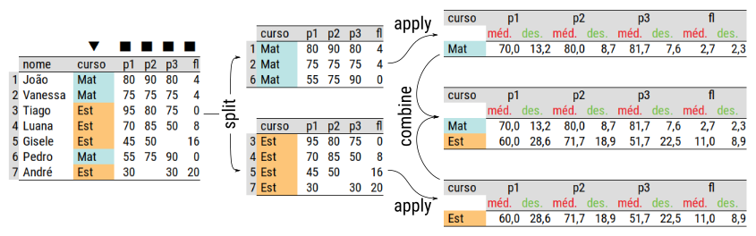

Agregação de uma tabela.

## Agregação

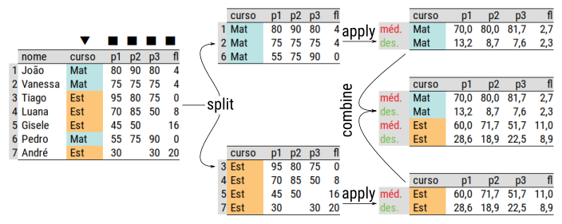

Agregação de uma tabela.

## Agregação

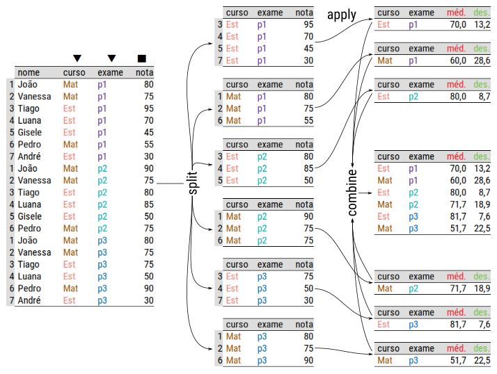

Agregação de uma tabela.

## Agregação

```python
# Agregações para conforme o curso.
df1.groupby(["curso"]).agg({"prova1": ["mean", "std"],
                            "prova2": ["mean", "std"],
                            "prova3": ["mean", "std"],
                            "faltas": ["mean", "std"]})

v = ["prova1", "prova2", "prova3", "faltas"]
df1.groupby(["curso"])[v].agg(["mean", "std"])
```

```python
# Empilhar nas provas.
df1_m = pd.melt(frame = df1,
                id_vars = ["curso"],
                value_vars = ["prova1", "prova2", "prova3"],
                var_name = "exame",
                value_name = "nota")
df1_m.groupby(["curso", "exame"])["nota"].\
    agg(["mean", "std"]).reset_index()
```

## Agregação

- Uma vez que uma tabela é agrupada, várias informações e métodos estão disponíveis.

```python
df1_by = df1.groupby("curso")
df1_by

# Propriedades da tabela agrupada.
df1_by.groups
df1_by.groups.keys()
df1_by.get_group("Est")

df1_by.get_group("Est").agg(["count", "mean", "std"])

# Estatísticas por grupo.
df1_by.prova1.count()
df1_by.prova1.mean()
```

## Concatenação

- A concatenação permite adicionar novas observações a uma tabela ou novas variáveis.
- O parâmetro `axis` é usado para indicar a direção: 0 - linhas, 1 - colunas.
- Seja por linha ou colunas, entradas com `NaN` são criadas para os índices que não foram especificados.
- Veja também a função `.append()`.

## Concatenação

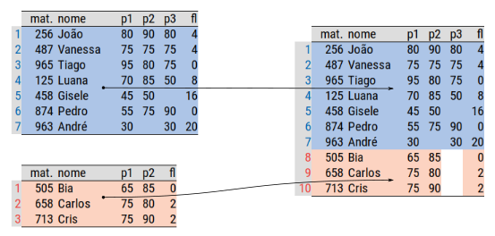

Concatenação de duas tabelas.

## Concatenação

```python
# Concatena com a tabela dos alunos de Eng.
pd.concat([df1, df2],
          axis = 0,
          ignore_index = True,
          sort = False)
```

```python
# Ilustrando como fazer para colunas.
pd.concat([df1.iloc[:5, :4],
           df1.iloc[2:, 4:]],
          axis = 1,
          ignore_index = False)
```

## Junções

- Junções permitem parear dados de tabelas separadas quando elas possuem uma chave (ou chave primária).
- As operações de junção podem ser inicialmente de 4 tipos:
  - Junção por interseção (*inner join*).
  - Junção por união (*full join*).
  - Junção à esquerda (*left join*).
  - Junção à direita (*right join*).
  - Existe também os *exclusive joins*.

## Junções

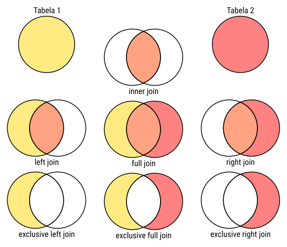

Tipos de junções de tabelas ilustrado com diagramas de Veen.

## Junções

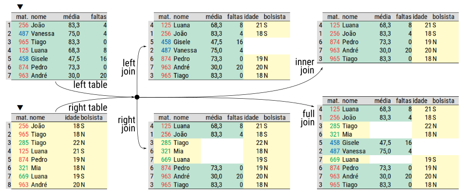

Junções de tabelas do tipo inclusivas.

## Junções

```python
df1 = df1.loc[:, ["matricula", "curso", "nome",
                  "prova1", "prova2", "prova3", "faltas"]]
df_extra.rename(columns = {"mat.": "matricula"},
                inplace = True)
```

```python
# How pode ser: inner, outer, left ou right.
pd.merge(left = df1, right = df_extra,
         how = "inner", on = ["nome", "matricula"])
```

```python
pd.merge(left = df1, right = df_extra,
         how = "outer", on = ["nome", "matricula"])
```

```python
pd.merge(left = df1, right = df_extra,
         how = "left", on = ["nome", "matricula"])
```

```python
pd.merge(left = df1, right = df_extra,
         how = "right", on = ["nome", "matricula"])
```

## Considerações

- Foram vistas as principais operações com dados tabulares.
- Para mais detalhes consulte a documentação e livros dedicados.
- Exercícios serão aplicados para fixação do conteúdo.
- Links para guias de referência e tutoriais serão dados no final.
- Conexão com banco de dados será visto em detalhe em outra disciplina.

## Gráficos

## Matplotlib e Seaborn

- [Matplotlib](https://matplotlib.org/) tem os recursos básicos para gráficos no Python.
- [Seaborn](https://seaborn.pydata.org/) é feita sobre a Matplotlib e constrói gráficos estatísticos.
- Objetos [Pandas](http://pandas.pydata.org/) possuem alguns métodos gráficos.

```python
import matplotlib.pyplot as plt
import seaborn as sns
```

## Histograma

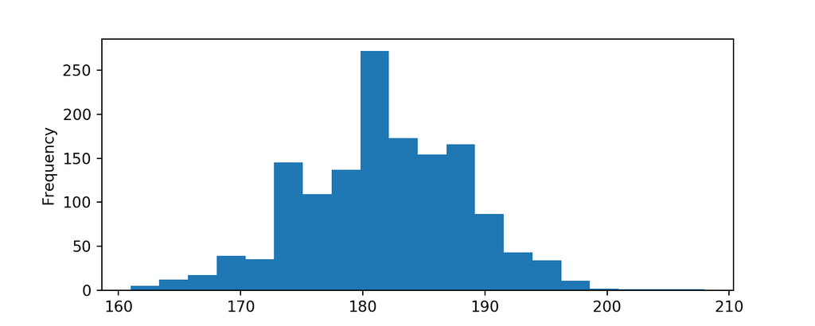

```python
tb["cm"].plot.hist(bins = 20)
plt.show()
```

## Densidade

```python
plt.close()
tb["cm"].plot.density(color = "red")
plt.show()
```

```python
plt.close()
tb2 = tb[tb.country.isin(["Italy", "England"])]
tb2.groupby(["country"])["cm"].plot.density()
```

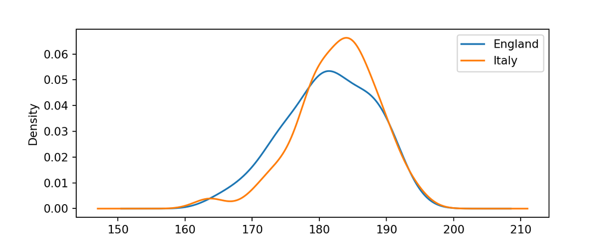

```python
plt.legend(); plt.show()
```

## Histograma e densidade

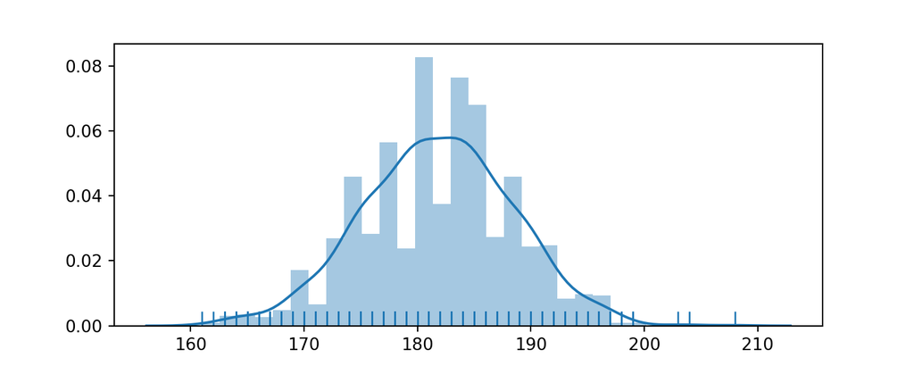

```python
plt.close()
sns.distplot(tb.loc[tb.cm.notnull(), ["cm"]],
             hist = True, kde = True, rug = True)
plt.show()
```

## Gráfico de barras

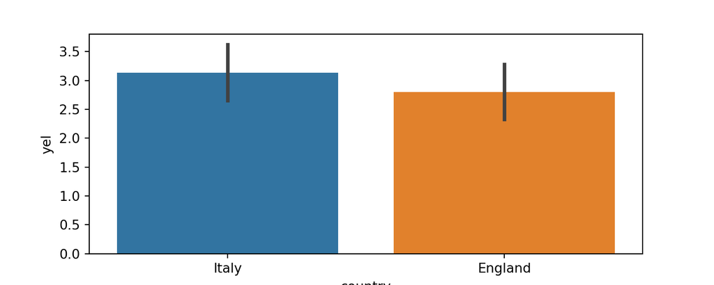

```python
plt.close()
sns.barplot(tb2.country, tb2.yel)
plt.show()
```

## Diagrama de dispersão

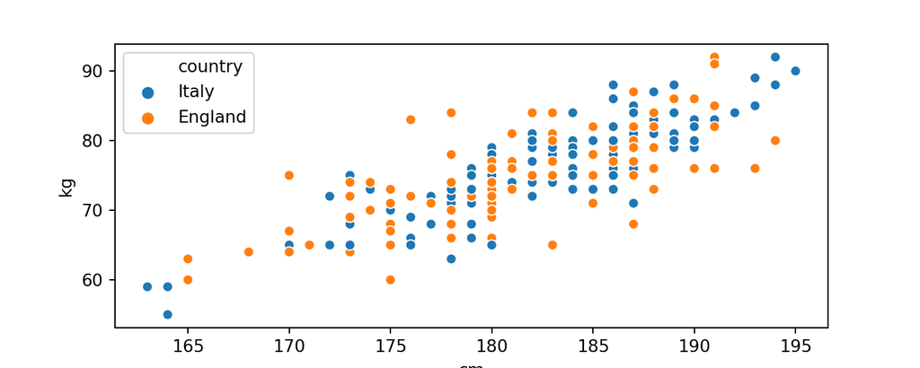

```python
plt.close()
sns.scatterplot(tb2.cm, tb2.kg, hue = tb2.country)
plt.show()
```

## Boxplot

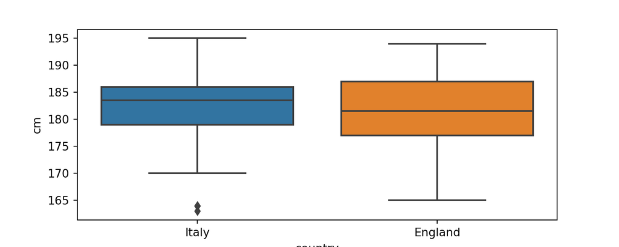

```python
plt.close()
sns.boxplot(tb2.country, tb2.cm)
plt.show()
```

## Violin plot

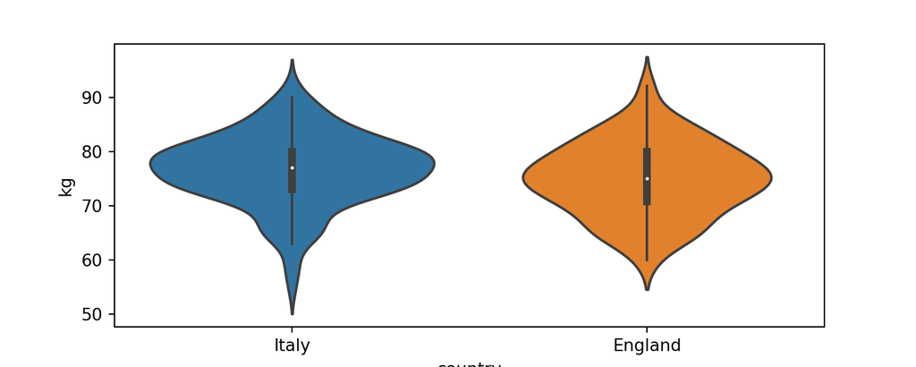

```python
plt.close()
sns.violinplot(tb2.country, tb2.kg)
plt.show()
```

## Matriz de diagramas de dispersão

```python
plt.close()
sns.pairplot(data = tb2, vars = ["cm", "kg", "age"], hue = "country")
```

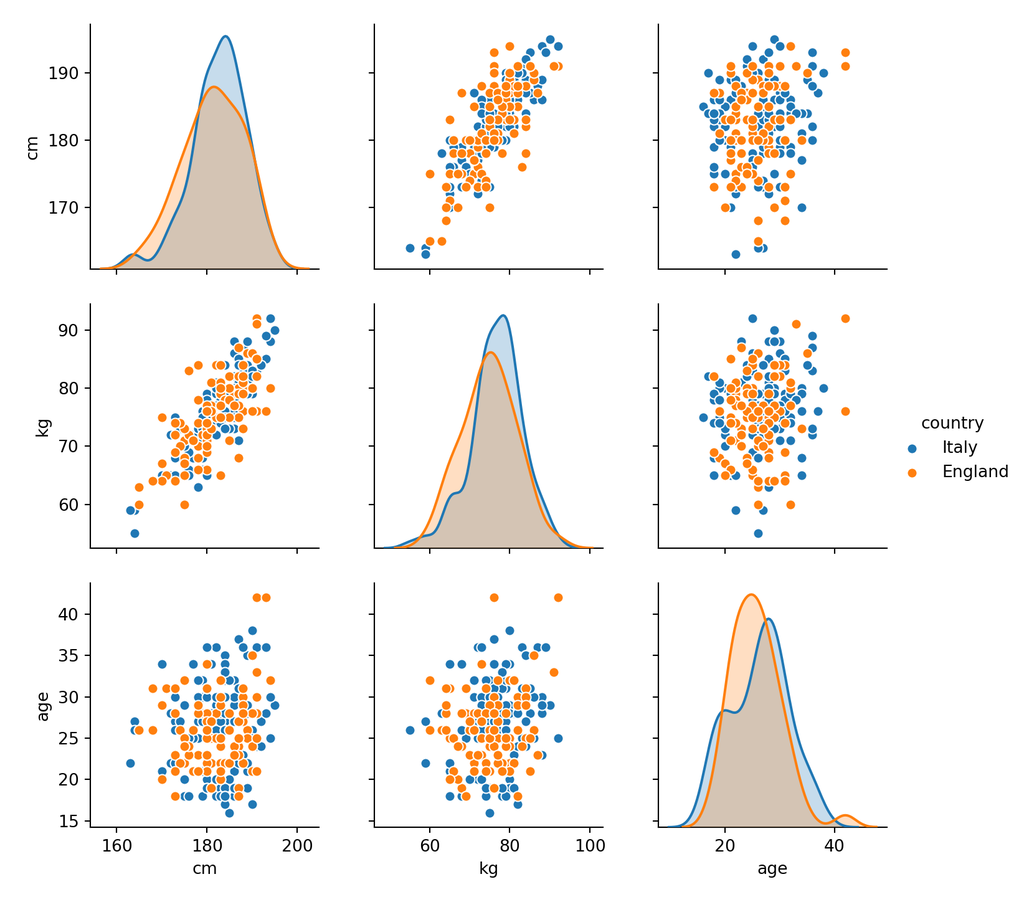

```python
plt.show()
```

## Considerações

- [Matplotlib](https://matplotlib.org/) e [Seaborn](https://seaborn.pydata.org/) confeccionam os principais gráficos.
- Eles estão prototipados como métodos ou funções.
- Os recursos não foram explorados em profundidade aqui.
- A customização dos gráficos requer maior conhecimento.
- A combinação de gráficos, adornos e anotações em gráficos também.

## Referências

## Referências

### Materiais

1. [Pandas not just for data scientists · Uzi Halaby Senerman](https://il.pycon.org/2016/static/sessions/uzi-hs.pdf).
2. [Introduction to Python Pandas for Data Analytics · Srijith Rajamohan](https://www.arc.vt.edu/wp-content/uploads/2016/08/pandas.pdf).
3. [Pandas Guide · Meher Krishna Patel](https://buildmedia.readthedocs.org/media/pdf/pandasguide/latest/pandasguide.pdf).
4. [Chris Albon webpage](https://chrisalbon.com/#python)
5. [Pandas Visualization](https://pandas.pydata.org/pandas-docs/stable/visualization.html).

## Referências

### Cartões de referência

1. [Data Analysis with PANDAS · Arianne Colton and Sean Chen](http://datasciencefree.com/pandas.pdf).
2. [Data Wrangling with Pandas](https://github.com/pandas-dev/pandas/blob/master/doc/cheatsheet/Pandas_Cheat_Sheet.pdf).
3. [Python for Data Science - Numpy](https://s3.amazonaws.com/assets.datacamp.com/blog_assets/Numpy_Python_Cheat_Sheet.pdf).
4. [Python for Data Science - Pandas](https://s3.amazonaws.com/assets.datacamp.com/blog_assets/Python_Pandas_Cheat_Sheet_2.pdf).
5. [Python for Data Science - Matplotlib](https://s3.amazonaws.com/assets.datacamp.com/blog_assets/Python_Matplotlib_Cheat_Sheet.pdf).
6. [Python for Data Science - Seaborn](https://s3.amazonaws.com/assets.datacamp.com/blog_assets/Python_Seaborn_Cheat_Sheet.pdf).
7. [The pandas DataFrame Object](http://www.webpages.uidaho.edu/~stevel/504/Pandas%20DataFrame%20Notes.pdf).

## Referências

### Principais livros

1. McKinney, Wes. [Python for data analysis: data wrangling with Pandas, NumPy, and IPython](https://books.google.com.br/books?id=BCc3DwAAQBAJ). Sebastopol, CA: O'Reilly Media, Inc, 2017. Print.
2. Chen, Daniel Y. [Pandas for everyone: Python data analysis](https://books.google.com.br/books?id=7zhDDwAAQBAJ). Boston: Addison-Wesley, 2018. Print.
3. Anthony, Femi. [Mastering pandas: master the features and capabilities of pandas, a data analysis toolkit for Python](https://books.google.com.br/books?id=qM_2CQAAQBAJ). Birmingham, UK: Packt Publishing, 2015. Print.
4. Dale, Kyran. [Data visualization with Python and JavaScript: scrape, clean, explore & transform your data](https://books.google.com.br/books?id=YSCTDAAAQBAJ). Sebastopol, CA: O'Reilly Media, 2016. Print.

## Exercícios

## Dados dos jogadores da liga européia (1)

1. Fazer a importação do arquivo disponível em http://leg.ufpr.br/~walmes/data/euro_football_players.txt.
2. Determinar o número de registros por pais (`country`).
3. Determinar o número de registros por time (`team`).
4. A média de idade (`age`) geral dos jogadores.
5. A mediana de peso (`kg`) geral dos jogadores.
6. Os percentis de 10 e 90% da distribuição da altura (`cm`).
7. Obter a correlação entre peso e altura.
8. A tupla do jogador com o maior número de gols (`goal`).
9. A tupla do jogador mais alto (`cm`).
10. Os 10 jogadores de maior rating (`rt`).
11. Os 10 jogadores mais altos (`cm`).

## Dados dos jogadores da liga européia (2)

1. Filtrar para jogadores que entraram em campo (`apps` > 0).
2. Imputar 0 no lugar dos valores ausentes em cartões amarelos (`yel`), vermelhos (`red`), gols (`goal`), e assistências a gol (`ass`).
3. Criar um variável com faixa de idade (`age`) em grupos de 5 anos.
4. Determinar o número de jogadores em cada faixa de idade.

## Dados dos jogadores da liga européia (3)

1. Criar a variável índice de massa corporal \[ \text{bmi} = \dfrac{\text{peso (kg)}}{\text{altura (m)}^2}. \]
2. Criar as faixa de índice de massa corporal.

   ```
   BMI < 18.5           : Below normal weight
   BMI >= 18.5 and < 25 : Normal weight
   BMI >= 25 and < 30   : Overweight
   BMI >= 30 and < 35   : Class I Obesity
   BMI >= 35 and < 40   : Class II Obesity
   BMI >= 40            : Class III Obesity
   ```

## Dados dos jogadores da liga européia (4)

1. Obter a média de idade por time.
2. Obter a mediana de peso por pais.
3. Obter a média de altura por posição em que joga.
4. Obter o rating médio por time.
5. Obter o jogador com mais gols em cada time.
6. Obter a proporção de jogadores italianos por time.
7. Obter a média, desvio-padrão e amplitude para número de gols por time.
8. Obter por time o total de gols, média de altura e amplitude de `bmi`.

## Próximo encontro e atividades

## Próximo encontro e atividades

### Será visto

1. Manipulação e visualização de dados no ambiente R.
2. Pacotes mais usados.
3. A abordagem tidyverse.

### Atividades no moodle

1. Fazer o quiz no moodle.
2. Fazer lista de exercícios extra.